# Bayesian Final Exam

Evan Walker

5/15/2019

```r
library(R2OpenBUGS)
library(lme4)
library(MASS)
library(ggplot2)
```

### Problem 1) We want to find the important predictors of fuel efficiency of cars. The file Cars.txt containing data on 92 cars, MPG and 11 covariate is available on blackboard.

```r
cars=read.table("Cars.txt",header=T)
summary(cars)
```

```
##       Type        Price         Cylinders       EngineSize
##  Compact:16   Min.   : 7.40   Min.   :3.000   Min.   :1.000
##  Large  :11   1st Qu.:12.18   1st Qu.:4.000   1st Qu.:1.875
##  Midsize:22   Median :17.60   Median :4.000   Median :2.400
##  Small  :21   Mean   :19.37   Mean   :4.967   Mean   :2.683
##  Sporty :13   3rd Qu.:22.85   3rd Qu.:6.000   3rd Qu.:3.300
##  Van    : 9   Max.   :61.90   Max.   :8.000   Max.   :5.700
##    Horsepower      Passengers       Length        Wheelbase
##  Min.   : 55.0   Min.   :2.00   Min.   :141.0   Min.   : 90
##  1st Qu.:102.8   1st Qu.:4.00   1st Qu.:174.8   1st Qu.: 98
##  Median :140.0   Median :5.00   Median :183.5   Median :103
##  Mean   :142.6   Mean   :5.12   Mean   :183.4   Mean   :104
##  3rd Qu.:170.0   3rd Qu.:6.00   3rd Qu.:192.2   3rd Qu.:110
##  Max.   :300.0   Max.   :8.00   Max.   :219.0   Max.   :119
##      Width           Weight         Origin        MPG
##  Min.   :60.00   Min.   :1695   non-USA:44   Min.   :17.50
##  1st Qu.:67.00   1st Qu.:2609   USA    :48   1st Qu.:22.00
##  Median :69.00   Median :3045                Median :24.50
##  Mean   :69.38   Mean   :3075                Mean   :25.78
##  3rd Qu.:72.00   3rd Qu.:3534                3rd Qu.:27.62
##  Max.   :78.00   Max.   :4105                Max.   :48.00
```

#### a) Use stepAIC() function in the MASS package to find the best linear regressiong model with respect to minimization of the AIC.

```r
basemod=lm(MPG~. , data=cars)
stepmod=stepAIC(basemod, direction = "both")
```

```
## Start:  AIC=190.53
## MPG ~ Type + Price + Cylinders + EngineSize + Horsepower + Passengers +
##     Length + Wheelbase + Width + Weight + Origin
##
##              Df Sum of Sq    RSS    AIC
## - Horsepower  1     0.246 515.63 188.57
## - EngineSize  1     0.754 516.14 188.66
## - Price       1     1.295 516.68 188.76
## - Length      1     1.549 516.93 188.80
## - Cylinders   1     8.798 524.18 190.08
## <none>                    515.38 190.53
## - Width       1    14.726 530.11 191.12
## - Origin      1    15.845 531.23 191.31
## - Wheelbase   1    17.037 532.42 191.52
## - Type        5    86.930 602.31 194.87
## - Passengers  1    55.587 570.97 197.95
## - Weight      1   111.509 626.89 206.55
##
## Step:  AIC=188.57
## MPG ~ Type + Price + Cylinders + EngineSize + Passengers + Length +
##     Wheelbase + Width + Weight + Origin
##
##              Df Sum of Sq    RSS    AIC
## - EngineSize  1     0.728 516.36 186.70
## - Price       1     1.055 516.68 186.76
## - Length      1     1.377 517.00 186.82
## - Cylinders   1     8.578 524.21 188.09
## <none>                    515.63 188.57
## - Origin      1    15.807 531.43 189.35
## - Width       1    15.947 531.57 189.37
## - Wheelbase   1    16.974 532.60 189.55
## + Horsepower  1     0.246 515.38 190.53
## - Type        5    88.710 604.34 193.18
## - Passengers  1    62.390 578.02 197.08
## - Weight      1   137.561 653.19 208.33
##
## Step:  AIC=186.7
## MPG ~ Type + Price + Cylinders + Passengers + Length + Wheelbase +
##     Width + Weight + Origin
##
```

[output cut: 34 more lines]

```
##     Origin
##
##              Df Sum of Sq    RSS    AIC
## <none>                    519.52 183.26
## - Origin      1    17.411 536.93 184.30
## + Price       1     1.736 517.79 184.96
## + Length      1     1.707 517.82 184.96
## + EngineSize  1     1.252 518.27 185.04
## - Cylinders   1    21.971 541.49 185.07
## - Wheelbase   1    22.367 541.89 185.14
## + Horsepower  1     0.087 519.44 185.25
## - Width       1    30.053 549.58 186.44
## - Type        5    97.513 617.04 189.09
## - Passengers  1    61.196 580.72 191.51
## - Weight      1   182.295 701.82 208.93
```

```r
summary(stepmod)
```

```
##
## Call:
## lm(formula = MPG ~ Type + Cylinders + Passengers + Wheelbase +
##     Width + Weight + Origin, data = cars)
##
## Residuals:
##     Min      1Q  Median      3Q     Max
## -4.7007 -1.1369 -0.1721  1.2440  9.3850
##
## Coefficients:
##              Estimate Std. Error t value Pr(>|t|)
## (Intercept) 14.537610  13.004364   1.118  0.26695
## TypeLarge    2.133889   1.631550   1.308  0.19466
## TypeMidsize -0.097166   1.000727  -0.097  0.92289
## TypeSmall    2.024765   1.170733   1.729  0.08758 .
## TypeSporty  -2.271798   1.380466  -1.646  0.10375
## TypeVan      1.865109   1.885336   0.989  0.32551
## Cylinders   -0.787009   0.427870  -1.839  0.06957 .
## Passengers  -1.922821   0.626376  -3.070  0.00293 **
## Wheelbase    0.214868   0.115778   1.856  0.06716 .
## Width        0.430463   0.200101   2.151  0.03448 *
## Weight      -0.008848   0.001670  -5.298 1.01e-06 ***
## OriginUSA   -1.104114   0.674301  -1.637  0.10547
## ---
## Signif. codes:  0 '***' 0.001 '**' 0.01 '*' 0.05 '.' 0.1 ' ' 1
##
## Residual standard error: 2.548 on 80 degrees of freedom
## Multiple R-squared:  0.8046, Adjusted R-squared:  0.7777
## F-statistic: 29.95 on 11 and 80 DF,  p-value: < 2.2e-16
```

As per usual with car data, Weight is the most significant predictor of MPG. With every unit increase of Weight, we expect a decrease in MPG by $-0.0088$. or, with every additional $113.6$ pounds, we expect to lose 1 mile per gallon from our mpg. (i.e. if a car has mpg 23, and we fill the trunk with $113$ pounds, we expect the mpg to decrease to 22 miles per gallon.)

#### b) Use Bayesian modeling to find the best linear regression model with respect to minimization of the DIC.

We make the assumption that the variables in the stepAIC model that minimizes the AIC are thesame variables that would minimize the DIC for a bayesian treatment of the linear regression

```r
d_baye=cars
d_baye$compact=ifelse(d_baye$Type=="Compact",1,0)
d_baye$large=ifelse(d_baye$Type=="Large",1,0)
d_baye$mid=ifelse(d_baye$Type=="Midsize",1,0)
d_baye$small=ifelse(d_baye$Type=="Small",1,0)
d_baye$sport=ifelse(d_baye$Type=="Sporty",1,0)
d_baye$van=ifelse(d_baye$Type=="Van",1,0)
d_baye$Origin= ifelse(d_baye$Origin=="USA",1,0)
d_baye=d_baye[,-1]

carsmodel <- function(){
    # likelihood
    for(i in 1:N)
    {
      y[i] ~ dnorm(mu[i], tau)
      mu[i] <- beta0 + beta1*cyl[i] + beta2*pas[i] + beta3*wid[i] + beta4*wb[i] +
        beta5*wt[i] +beta6_1*comp[i]+beta6_2*large[i]+beta6_3*mid[i]+
        beta6_4*small[i]+beta6_5*sport[i]+beta6_6*van[i]
    }
    # priors
    beta0 ~ dnorm(0,0.001)
    beta1 ~ dnorm(0,0.001)
    beta2 ~ dnorm(0,0.001)
    beta3 ~ dnorm(0,0.001)
    beta4 ~ dnorm(0,0.001)
    beta5 ~ dnorm(0,0.001)
    beta6_1 ~ dnorm(0,0.001)
    beta6_2 ~ dnorm(0,0.001)
    beta6_3 ~ dnorm(0,0.001)
    beta6_4 ~ dnorm(0,0.001)
    beta6_5 ~ dnorm(0,0.001)
    beta6_6 ~ dnorm(0,0.001)
    sigma ~ dunif(0,100)
    tau <- 1/(sigma*sigma)

  }

  write.model(carsmodel, "carsmodel.txt")

  data=list(cyl=d_baye$Cylinders, pas=d_baye$Passengers,
            wid=d_baye$Width, wb=d_baye$Wheelbase, wt=d_baye$Weight,
            comp=d_baye$compact, large=d_baye$large, mid=d_baye$mid,
            small=d_baye$small, sport=d_baye$sport, van=d_baye$van,
            N=nrow(d_baye), y=d_baye$MPG)

  inits=list(list(beta0 = rnorm(1,0,10000), beta1 = rnorm(1,0,10000),
                  beta2 = rnorm(1,0,10000), beta3 = rnorm(1,0,10000),
                  beta4 = rnorm(1,0,10000), beta5 = rnorm(1,0,10000),
                  beta6_1 = rnorm(1,0,10000), beta6_2 = rnorm(1,0,10000),
                  beta6_3 = rnorm(1,0,10000), beta6_4 = rnorm(1,0,10000),
                  beta6_5 = rnorm(1,0,10000), beta6_6 = rnorm(1,0,10000)))

  parameters <- c("beta0","beta1","beta2","beta3","beta4",
                  "beta5","beta6_1","beta6_2","beta6_3",
                  "beta6_4","beta6_5","beta6_6","sigma",
                  "tau","mu")

  cars.sim <- bugs(data, inits, parameters, "carsmodel.txt",n.chains=1,n.burnin=10000, n.iter=20000,DIC=T)

  cars.sim$summary[1:14,1:7]
```

```
##                 mean           sd       2.5%       25%        50%
## beta0   -29.92070444 21.506227679 -62.720250 -51.96000 -23.325000
## beta1    -1.34958008  0.912217858  -4.336000  -1.57825  -1.200000
## beta2    -2.79827507  1.228904962  -6.581250  -3.26000  -2.549000
## beta3     0.91079656  0.797177012   0.159100   0.47080   0.597250
## beta4     0.29275188  0.192317362  -0.442105   0.26100   0.343200
## beta5    -0.01021859  0.001818357  -0.014560  -0.01126  -0.009969
## beta6_1  14.40971819 17.180415105 -32.900000   1.28350  19.635000
## beta6_2  14.86652962 17.339909515 -31.291000   1.34200  19.895000
## beta6_3  13.81191648 17.288382213 -33.270250   0.68600  18.970000
## beta6_4  16.61600994 17.747788335 -33.890250   3.91250  21.980000
## beta6_5  10.67728255 19.283982378 -46.351500  -1.57375  16.670000
## beta6_6  16.43701492 16.423884535 -25.671250   2.83150  20.825000
## sigma     2.99039000  0.811139582   2.298000   2.56000   2.743000
## tau       0.12667510  0.038810019   0.029829   0.10840   0.132900
##                75%        97.5%
## beta0   -10.140000  2.393025000
## beta1    -0.845600 -0.145587500
## beta2    -2.011000 -1.111950000
## beta3     1.037000  3.525024997
## beta4     0.394000  0.465802500
## beta5    -0.008947 -0.007337975
## beta6_1  26.030000 41.730250000
## beta6_2  27.040000 42.410750000
## beta6_3  25.790000 41.180750000
## beta6_4  28.080000 44.650250000
## beta6_5  23.390000 39.711250000
## beta6_6  28.430000 42.261500000
## sigma     3.037000  5.790099966
## tau       0.152525  0.189302499
```

```r
  cars.sim$DIC
```

```
## [1] 472.4
```

#### c) Give interpretation of the coefficients and compare the results.

```r
sims=cars.sim$sims.list
summary(sims$beta5)
```

```
##      Min.   1st Qu.    Median      Mean   3rd Qu.      Max.
## -0.017250 -0.011260 -0.009969 -0.010219 -0.008947 -0.006186
```

```r
library(knitr)
mean_baye=as.numeric(cars.sim$mean[-c(13,14,15,16,17,18)])
mean_baye[c(8,9,10,11,12)]=mean_baye[c(8,9,10,11,12)]-mean_baye[7]
mean_baye=mean_baye[-7]
mean_ML=stepmod$coefficients
d=data.frame(inter=c(mean_baye[1],mean_ML[1]), cyl=c(mean_baye[2],mean_ML[7]),
             pas=c(mean_baye[3],mean_ML[8]), wid=c(mean_baye[4],mean_ML[10]),
             wb=c(mean_baye[5],mean_ML[9]), wt=c(mean_baye[6],mean_ML[11]),
             large=c(mean_baye[7],mean_ML[2]), mid=c(mean_baye[8],mean_ML[3]),
             small=c(mean_baye[9],mean_ML[4]), sport=c(mean_baye[10],mean_ML[5]),
             van=c(mean_baye[11],mean_ML[6]))

d=as.data.frame(t(d))
colnames(d)=c("Bayes","ML")
d$diff=abs(d$Bayes-d$ML)
kable(d)
```

|  | Bayes | ML | diff |
| --- | --- | --- | --- |
| inter | -29.9207044 | 14.5376096 | 44.4583141 |
| cyl | -1.3495801 | -0.7870090 | 0.5625710 |
| pas | -2.7982751 | -1.9228215 | 0.8754536 |
| wid | 0.9107966 | 0.4304628 | 0.4803337 |
| wb | 0.2927519 | 0.2148685 | 0.0778834 |
| wt | -0.0102186 | -0.0088478 | 0.0013708 |
| large | 0.4568114 | 2.1338889 | 1.6770775 |
| mid | -0.5978017 | -0.0971661 | 0.5006357 |
| small | 2.2062918 | 2.0247648 | 0.1815270 |
| sport | -3.7324356 | -2.2717977 | 1.4606379 |
| van | 2.0272967 | 1.8651094 | 0.1621873 |

The values of the Maximum likilehood approach versus Bayesian approach have somewhat similar. we expect some differences since the step model included non-significant Origin of car, which wew threw out for the bayesian approach. Taking note of the standard deviation of the coefficients from the bayesian model, the table above should not be the greatest indicator of how well the models match since the deviance of the intercept and type of car is very large.

#### d) Simulate 1000 replication samples from the posterior predictive distribution.

```r
N=nrow(d_baye)
sims=cars.sim$sims.list
mu=sims$mu
tau=sims$tau
#mu,tau
n.sims=1000
#theta <- array(NA, c(n.sims, N))
y.rep <- array (NA, c(n.sims, N))
for (sim in 1:n.sims){
  y.rep[sim,] <- rnorm (N, mean=mu[sim,], sd=tau)
}
dim(y.rep)
```

```
## [1] 1000   92
```

for each of the 92 cars MPG’s, we have a sample of 1000 replications from the posterior distribution. Resulting a distribution of replicated samples for each of the cars MPG

#### e) Show that the best model form part b) is a good model by calculating Bayesian p-values for the number of cars with MPG over 35 and under 20.

definition of bayesian p-values is,

$$P(T(y_{rep},\theta)\geq T(y,\theta)|y)$$

We look for the proportion of cars with $y_{rep} \leq 20$, and $y_{rep} \geq 35$.

$$P\Big((y_{rep} \leq 20) \bigcup (y_{rep} \geq 35)\Big)=1-P(20 \leq y_{rep} \leq 35)$$

```r
#mean difference of the means
mean(cars$MPG-colMeans(y.rep))
```

```
## [1] -0.004800384
```

```r
#bayesian p-value
p=sum(I(20<=y.rep&y.rep<=35))/(1000*92)
1-p
```

```
## [1] 0.1968913
```

From the original data, we have that,

```r
p=sum(I(20<=d_baye$MPG&d_baye$MPG<=35))/92
1-p
```

```
## [1] 0.09782609
```

### Problem 2) Let $Y|\theta \sim N(X\theta,\Sigma)$ be a linear regression model.

where $Y$ is a $n \times 1$ containing the outcome variable of interest, $\theta$ is a $p \times 1$ vector containing the effect sizes, $X$ is a known $n \times p$ matrix of covariate values and $\Sigma$ isa known $n \times n$. We adopt the following prior $\theta \sim N(X_1\theta_1,\Sigma_1)$, where $\theta_1$ is a knwon $p_{1} \times 1$ ,$X_1$ is a known $p \times p_1$ matrix and $\Sigma_1$ is a knwon $p \times p$ covariance matrix.

#### a) Find the marginal distribution of $Y$.

if,
$$Y|\theta \sim N(X\theta, \Sigma) \\
\theta \sim N(X_1 \theta_1,\Sigma_1)$$
$\Longrightarrow$

$$p(Y|\theta)= (2\pi)^{-p/2} |\Sigma|^{-1/2} e^{-(Y-X\theta)^T\Sigma^{-1}(Y-X\theta)/2}$$
and,

$$p(\theta)=(2\pi)^{-p_1/2} |\Sigma_1|^{-1/2} e^{-(\theta-X_1\theta_1)^T\Sigma_1^{-1}(\theta-X_1\theta_1)/2}$$

$p(y)$ can be found,

$$\begin{equation}
\begin{split}
p(y) &= \int_{-\infty}^{\infty} p(y|\theta)p(\theta) d\theta \\
&= (2\pi)^{-p_1/2} |\Sigma_1|^{-1/2} (2\pi)^{-p/2} |\Sigma|^{-1/2}\int_{-\infty}^{\infty}
e^{-\Big[(Y-X\theta)^T\Sigma^{-1}(Y-X\theta)+(\theta-X_1\theta_1)^T\Sigma_1^{-1}(\theta-X_1\theta_1)\Big]/2}d\theta
\end{split}
\end{equation}$$

Working just with the exponent,

$$\begin{equation}
\begin{split}
(Y-X\theta)^T\Sigma^{-1}(Y-X\theta)+(\theta-X_1\theta_1)^T\Sigma_1^{-1}(\theta-X_1\theta_1) &=
Y^T\Sigma^{-1}Y - Y^T\Sigma^{-1}X\theta-(X\theta)^T\Sigma^{-1}Y + (X\theta)^T\Sigma^{-1}(X\theta) + \\
& \theta^T\Sigma_1^{-1}\theta-\theta^T\Sigma_1^{-1}(X_1\theta_1)-(X_1\theta_1)^T\Sigma_1^{-1}\theta + (X_1\theta_1)^T\Sigma_1^{-1}(X_1\theta_1)\\
&= -2Y^T\Sigma^{-1}X\theta+ (X\theta)^T\Sigma^{-1}(X\theta) + \theta^T\Sigma_1^{-1}\theta -2(X_1\theta_1)^T\Sigma_1^{-1}\theta
\end{split}
\end{equation}$$
The last line is derived by dropping quadratic forms that do not depend on $\theta$, and the fact that if a matrix $A$ is positive definite and symetric, then $b^TA^{-1}a = a^TA^{-1}b$. The quadratic forms dropped are not forgotten, but they play no role in the integral so we shall take them out as scaling factors. We make the conjecture that $\theta$ is distributed multivariate normal with some unknown mean $\mu_n$ and unkown covariance matrix $\Lambda_n$. The goal is to find that $\theta$ is normal and hence we can reduce the integral to 1 if we scale it properly. Hence,

$$\begin{equation}
\begin{split}
(\theta-\mu_n)^T\Lambda_n^{-1}(\theta-\mu_n) &= -2Y^T\Sigma^{-1}X\theta+ (X\theta)^T\Sigma^{-1}(X\theta) + \theta^T\Sigma_1^{-1}\theta
-2(X_1\theta_1)^T\Sigma_1^{-1}\theta \\
\theta^T\Lambda_n^{-1}\theta -2\mu_n^T\Lambda_n^{-1}\theta+\mu_n^T\Lambda_n^{-1}\mu_n &= -2Y^T\Sigma^{-1}X\theta+ (X\theta)^T\Sigma^{-1}(X\theta) +
\theta^T\Sigma_1^{-1}\theta -2(X_1\theta_1)^T\Sigma_1^{-1}\theta \\
\end{split}
\end{equation}$$
$\Longrightarrow$

$$\begin{equation}
\begin{split}
-2\mu_n^T\Lambda_n^{-1}\theta &= -2Y^T\Sigma^{-1}X\theta -2(X_1\theta_1)^T\Sigma_1^{-1}\theta \\
&=-2\Big[( Y^T\Sigma^{-1}X +(X_1\theta_1)^T\Sigma_1^{-1} ) \Lambda_n\Big]\Lambda_n^{-1} \theta \\
\Longrightarrow \mu_n^T&=Y^T\Sigma^{-1}X\Lambda_n +(X_1\theta_1)^T\Sigma_1^{-1}\Lambda_n
\end{split}
\end{equation}$$

and,

$$\begin{equation}
\begin{split}
\theta^T\Lambda_n^{-1}\theta +\mu_n^T\Lambda_n^{-1}\mu_n &= (X\theta)^T\Sigma^{-1}(X\theta) +\theta^T\Sigma_1^{-1}\theta \\
&=\theta^TX^T\Sigma^{-1}X\theta +\theta^T\Sigma_1^{-1}\theta \\
&= \theta^T(X^T\Sigma^{-1}X +\Sigma_1^{-1})\theta \\
\Longrightarrow \Lambda_n^{-1} &= X^T\Sigma^{-1}X +\Sigma_1^{-1} \\
\Longrightarrow \Lambda_n &= (X^T\Sigma^{-1}X +\Sigma_1^{-1})^{-1}
\end{split}
\end{equation}$$
and finally, $\Longrightarrow$
$$\mu_n^T=Y^T\Sigma^{-1}X(X^T\Sigma^{-1}X +\Sigma_1^{-1})^{-1} +(X_1\theta_1)^T\Sigma_1^{-1}(X^T\Sigma^{-1}X +\Sigma_1^{-1})^{-1}$$

using this, we can setup the integral to integrate to 1,

$$\begin{equation}
\begin{split}
p(y) &= \int_{-\infty}^{\infty} p(y|\theta)p(\theta) d\theta \\
&= (2\pi)^{-p_1/2} |\Sigma_1|^{-1/2} (2\pi)^{-p/2} |\Sigma|^{-1/2}
\Bigg[ e^{\Big[-Y^T\Sigma^{-1}Y-(X_1\theta_1)^T\Sigma_1^{-1}(X_1\theta_1)\Big]/2} \Bigg] (2\pi)^{-p/2}(2\pi)^{p/2} |\Lambda_{n}|^{-1/2} |\Lambda_{n}|^{1/2}
\int_{-\infty}^{\infty}e^{ (\theta-\mu_n)^T\Lambda_n^{-1}(\theta-\mu_n)/2}d\theta \Bigg] \\
&= (2\pi)^{-p_1/2} |\Sigma_1|^{-1/2} (2\pi)^{-p/2} |\Sigma|^{-1/2}(2\pi)^{p/2}|\Lambda_{n}|^{1/2}
e^{\Big[-Y^T\Sigma^{-1}Y-(X_1\theta_1)^T\Sigma_1^{-1}(X_1\theta_1)\Big]/2} \\
&= (2\pi)^{-p_1/2}\frac{\sqrt{|\Lambda_n|}}{\sqrt{|\Sigma_1||\Sigma|}} e^{\Big[-Y^T\Sigma^{-1}Y-(X_1\theta_1)^T\Sigma_1^{-1}(X_1\theta_1)\Big]/2}\\
&\propto exp{\Big[-\Big(Y^T\Sigma^{-1}Y+(X_1\theta_1)^T\Sigma_1^{-1}(X_1\theta_1)\Big)/2 \Big]}
\end{split}
\end{equation}$$

#### b) Find the posterior distribution of $\theta$.

$$\begin{equation}
\begin{split}
p(\theta|Y)&=\frac{p(y|\theta)p(\theta)}{p(y)} \\
&= \frac{(2\pi)^{-p/2} |\Sigma|^{-1/2} (2\pi)^{-p_1/2} |\Sigma_1|^{-1/2} exp\Big[-(Y-X\theta)^T\Sigma^{-1}(Y-X\theta)/2\Big]
exp\Big[-(\theta-X_1\theta_1)^T\Sigma_1^{-1}(\theta-X_1\theta_1)/2\Big]}{(2\pi)^{-p_1/2} |\Sigma_1|^{-1/2} (2\pi)^{-p/2}
|\Sigma|^{-1/2}(2\pi)^{p/2}|\Lambda_{n}|^{1/2} exp\Big[-(Y^T\Sigma^{-1}Y+(X_1\theta_1)^T\Sigma_1^{-1}(X_1\theta_1))/2\Big]} \\
&=(2\pi)^{-p/2}|\Lambda_{n}|^{-1/2} exp\Big[ -\Big((Y-X\theta)^T\Sigma^{-1}(Y-X\theta) +(\theta-X_1\theta_1)^T\Sigma_1^{-1}(\theta-X_1\theta_1)-
Y^T\Sigma^{-1}Y-(X_1\theta_1)^T\Sigma_1^{-1}(X_1\theta_1)\Big)/2\Big]
\end{split}
\end{equation}$$

we can expand the exponent and 2 terms will cancel, but for readability, I will leave it in that form.

#### c) Apply the formula from part b) using the simplifying arguments, $\Sigma=\sigma^2I$ and $\Sigma_{1}^{-1}=0$ and discuss the result.

$$\begin{equation}
\begin{split}
p(\theta|Y) &=(2\pi)^{-p/2}|\Lambda_{n}|^{-1/2} exp\Big[ -\Big((Y-X\theta)^T\Sigma^{-1}(Y-X\theta) +(\theta-X_1\theta_1)^T\Sigma_1^{-1}(\theta-X_1\theta_1)-
Y^T\Sigma^{-1}Y-(X_1\theta_1)^T\Sigma_1^{-1}(X_1\theta_1)\Big)/2\Big] \\
&=(2\pi)^{-p/2}\frac{1}{\sqrt{\sigma^2}}|X^TX|^{-1/2} exp\Big[ -\Big(\frac{1}{\sigma^2}(Y-X\theta)^T(Y-X\theta)+\frac{1}{\sigma^2}Y^TY\Big)/2\Big] \\
&=\frac{(2\pi)^{-p/2}}{\sqrt{\sigma^2|X^TX|}} e^{-(Y-X\theta)^T(Y-X\theta)/2\sigma^2}e^{-Y^TY/2\sigma^2}
\end{split}
\end{equation}$$

Looks extremely close to Classical regression models

### Problem 3) Fast food

restaurant managers want know if burger patties stored in expensive high quality and low temperature freezers produce better tasting burgers. They stored 16 patties in a normal and 16 in a high quality freezer. 16 subjects were given both types of patties in a random order to reduce order bias. The study was double-blind, neither the servers nor the customers knew which patty was which. The results were that 14 of the customers preferred teh expensive freezer patty. Let the probability that a particular customer chooses the expensive freezer patty was $\theta$.

#### a) Find the posterior distribution of $\theta$ if we adopt Jeffrey’s prior.

Let $n=16$ and let $y$ be counted as a $1$ if the customer prefers the expensive freezer patty, and $0$ if they don’t. $\Longrightarrow$

$$y|\theta \sim Bin(n,\theta)$$

then,

$$p(y|\theta) = \prod_{i=1}^{n} \binom{n}{y_i}\theta^{y_i}(1-\theta)^{1-y_i} = \theta^{\sum y_{i}}(1-\theta)^{n-\sum y_{i}}\prod_{i=1}^{n}\binom{n}{y_{i}}$$
$\Longrightarrow$

$$p(y|\theta) \propto \theta^{\sum y_{i}}(1-\theta)^{n-\sum y_{i}}$$

and if we adopt Jeffreys prior, then

$$p(\theta) \sim \sqrt{-E\Bigg(\frac{\delta^2log(p(y|\theta))}{\delta\theta^2}|\theta\Bigg)}$$
starting inside out from Jeffrey’s prior,

$$log(p(y|\theta))=\sum_{i=1}^{n}log\binom{n}{y_{i}}+log(\theta)\sum_{i=1}^{n}y_{i}+(n-\sum_{i=1}^{n}y_{i})log(1-\theta)$$

$$\frac{\delta(log(p(y|\theta)))}{\delta\theta}=\frac{\sum_{i=1}^{n}y_{i}}{\theta}-\frac{n-\sum_{i=1}^{n}y_{i}}{1-\theta}$$

$$\frac{\delta^2log(p(y|\theta))}{\delta\theta^2}=-\frac{\sum_{i=1}^{n}y_{i}}{\theta^2}-\frac{n-\sum_{i=1}^{n}y_{i}}{(1-\theta)^2}$$

$$\begin{equation}
\begin{split}
-E\Bigg(\frac{\delta^2log(p(y|\theta))}{\delta\theta^2}|\theta\Bigg)&=\frac{E(\sum_{i=1}^{n}y_{i})}{\theta^2}+\frac{n-E(\sum_{i=1}^{n}y_{i})}{(1-\theta)^2}\\
&=\frac{n\theta}{\theta^2}+\frac{n-n\theta}{(1-\theta)^2}\\
&=\frac{n}{\theta} + \frac{n}{(1-\theta)} \\
&=\frac{n}{\theta(1-\theta)}
\end{split}
\end{equation}$$

by definition of expected value of binomial.

and finally,

$$\sqrt{J(\theta)}= \sqrt{\frac{n}{\theta(1-\theta)}} =\sqrt{n}\theta^{-\frac{1}{2}}(1-\theta)^{-\frac{1}{2}}$$

$\Longrightarrow$
$$p(\theta) \propto \theta^{\frac{1}{2}-1} (1-\theta)^{\frac{1}{2}-1} \sim Beta\Big(\frac{1}{2},\frac{1}{2} \Big)$$

then we have all the necessary pieces to compute the posterior,

$$\begin{equation}
\begin{split}
p(\theta|y)&=\frac{p(y|\theta)\sqrt{J(\theta)}}{p(y)} \\
&\propto \theta^{\sum y_{i}}(1-\theta)^{n-\sum y_{i}} \theta^{\frac{1}{2}}(1-\theta)^{\frac{1}{2}} \\
&=\theta^{\sum y_{i}-\frac{1}{2}}(1-\theta)^{n-\sum y_{i}-\frac{1}{2}} \\
&=\theta^{(\sum y_{i}+\frac{1}{2})-1}(1-\theta)^{(n-\sum y_{i}+\frac{1}{2})-1}\\
&\sim Beta\Big(\sum y_{i}+\frac{1}{2},n-\sum y_{i}+\frac{1}{2} \Big)
\end{split}
\end{equation}$$
$\Longrightarrow p(\theta|y) \sim Beta\Big(\sum y_{i}+\frac{1}{2},n-\sum y_{i}+\frac{1}{2} \Big)$

and plugging in,

$$\sum y_{i} = 14, \quad n=16$$
then,
$$p(\theta|y)\sim Beta\Big(14.5, 2.5\Big)$$
and has shape,

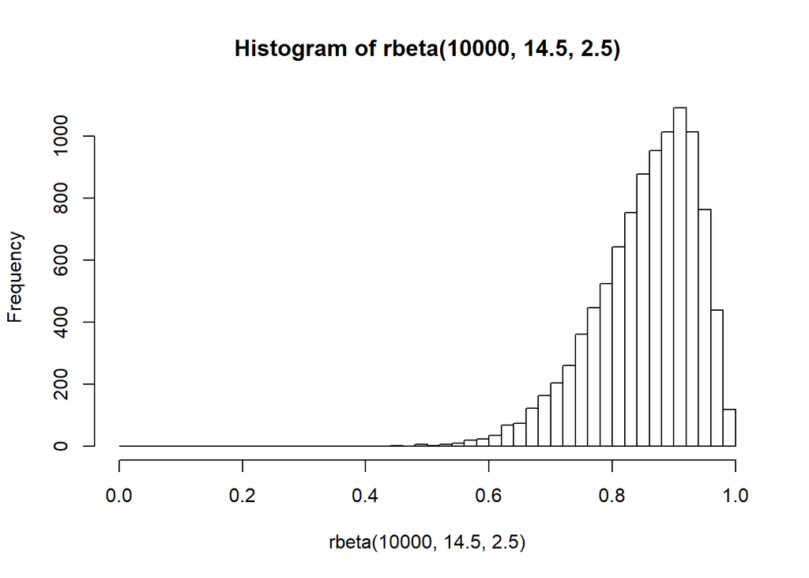

```r
hist(rbeta(10000, 14.5, 2.5),breaks=seq(0,1,by=.02))
```

#### b) Use Bayes factors to compute the hypothesis,

$$H_1 : \theta \geq 0.7 \\
H_2 : \theta < 0.7 \\$$
using the definition of Bayes factors,

$$\begin{equation}
\begin{split}
BF(H_2,H_1) &=\frac{p(y|H_2)}{p(y|H_1)} \\
&=\frac{p(y|\theta < 0.7)}{p(y|\theta \geq 0.7)} \\
&=\frac{\int_{0}^{0.7}\theta^{\sum y_{i}}(1-\theta)^{n-\sum y_{i}}d\theta }{\int_{0.7}^{1}
\theta^{\sum y_{i}}(1-\theta)^{n-\sum y_{i}}d\theta }\\
&=\frac{\int_{0}^{0.7}\theta^{14}(1-\theta)^{2}d\theta }{\int_{0.7}^{1}\theta^{14}(1-\theta)^{2}d\theta }
\end{split}
\end{equation}$$

Recognizing that the distribution is $Beta(15,3)$, we can approximate in R by

```r
int_0_7=pbeta(0.7, 15, 3) - pbeta(0, 15, 3)
int_7_1=pbeta(1, 15, 3) - pbeta(0.7, 15, 3)
int_0_7+int_7_1  # sanity check
```

```
## [1] 1
```

```r
BF21=int_0_7/int_7_1
BF21
```

```
## [1] 0.08387602
```

```r
BF12=int_7_1/int_0_7
BF12
```

```
## [1] 11.92236
```

and has shape

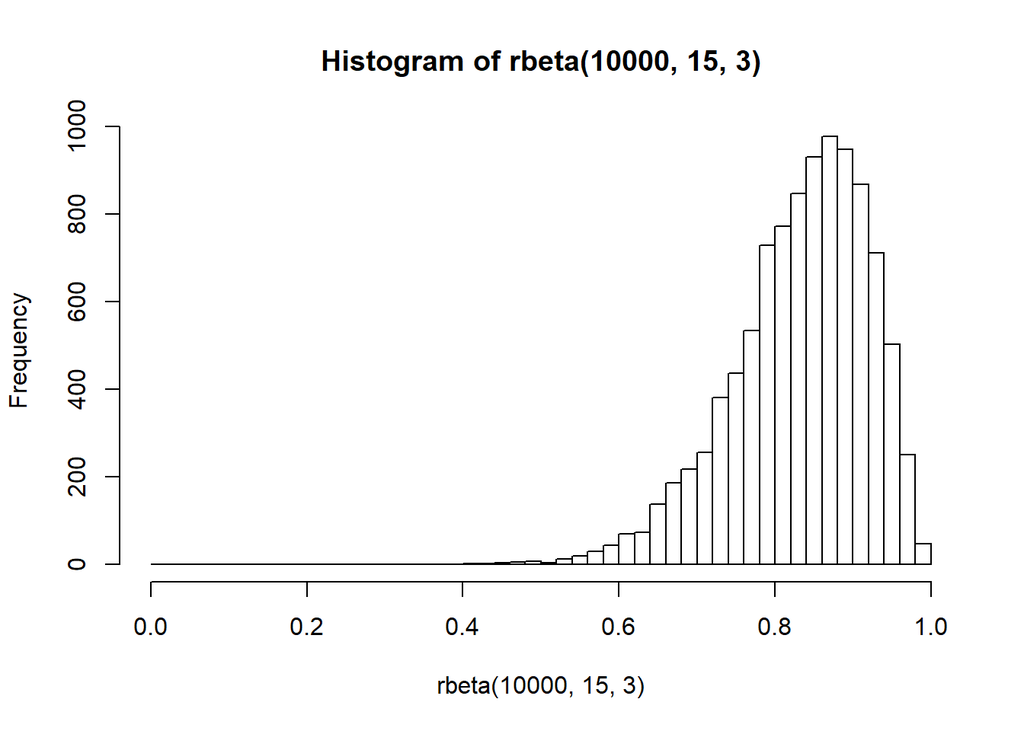

```r
hist(rbeta(10000, 15, 3),breaks=seq(0,1,by=.02))
```

Then,

$$\begin{equation}
\begin{split}
BF(H_2,H_1) &=\frac{\int_{0}^{0.7}\theta^{14}(1-\theta)^{2}d\theta }{\int_{0.7}^{1}\theta^{14}(1-\theta)^{2}d\theta } \\
&\approx \frac{0.0773}{0.9226}=0.08387
\end{split}
\end{equation}$$

or, $B(H_1,H_2) = 11.9223$

Then we can conclude that it is much more probable that we observe $H_1: \theta \geq 0.7$.

in fact, the maximum likelihood estimate is of $\theta$ is

$$\hat{\theta}_{ML}= \frac{14}{16}=0.875$$